# PML - Course Project

Fabrice LEBEL

## 1. Introduction

The purpose of this study is to use data from fitness devices and use them to predict if a user performes correctly or not barbell lifts. Our approach is to

1. Perform exploratory analysis and data cleanup on the training set
2. Study 2 classification models on the training set based on the following algorithms
- classification tree
- random forest
3. Apply the trained models to a test set.

## 2. Exploratory Analysis and Data Cleaning

The data set is divided in 2 separate sets: a training set and a test set. The data cleanup and feature selection process used the following steps:

1. By examining the training set with the **describe** function from the **psych** package we can see that several **predictors contain NAs and/or no data**. We remove these variables from the training set. We end up with **59 possible predictors** for the ‘classe’ outcome.
2. We remove all the qualitative predictors.
3. As we want predictors not correlated 2 by 2, we perform a correlation analysis between quantitative predictors using the **findCorrelation** function from the **caret** package with a cutoff value of 0.7. We remove predictors with the largest mean absolute correlation. **We end up with 30 predictors** which are the following

```
##  [1] "gyros_belt_x"         "gyros_belt_y"         "gyros_belt_z"
##  [4] "magnet_belt_x"        "magnet_belt_z"        "roll_arm"
##  [7] "pitch_arm"            "yaw_arm"              "total_accel_arm"
## [10] "gyros_arm_x"          "gyros_arm_z"          "magnet_arm_x"
## [13] "magnet_arm_z"         "roll_dumbbell"        "pitch_dumbbell"
## [16] "yaw_dumbbell"         "total_accel_dumbbell" "gyros_dumbbell_y"
## [19] "gyros_dumbbell_z"     "magnet_dumbbell_z"    "roll_forearm"
## [22] "pitch_forearm"        "yaw_forearm"          "total_accel_forearm"
## [25] "gyros_forearm_x"      "accel_forearm_x"      "accel_forearm_z"
## [28] "magnet_forearm_x"     "magnet_forearm_y"     "magnet_forearm_z"
```

4. We **split the training set in 2**: 60% for training, 40% for validation.

## 3. Models

### 3.1 Classification Tree

Our first predictive model is a **classification tree**. We have the following tree:

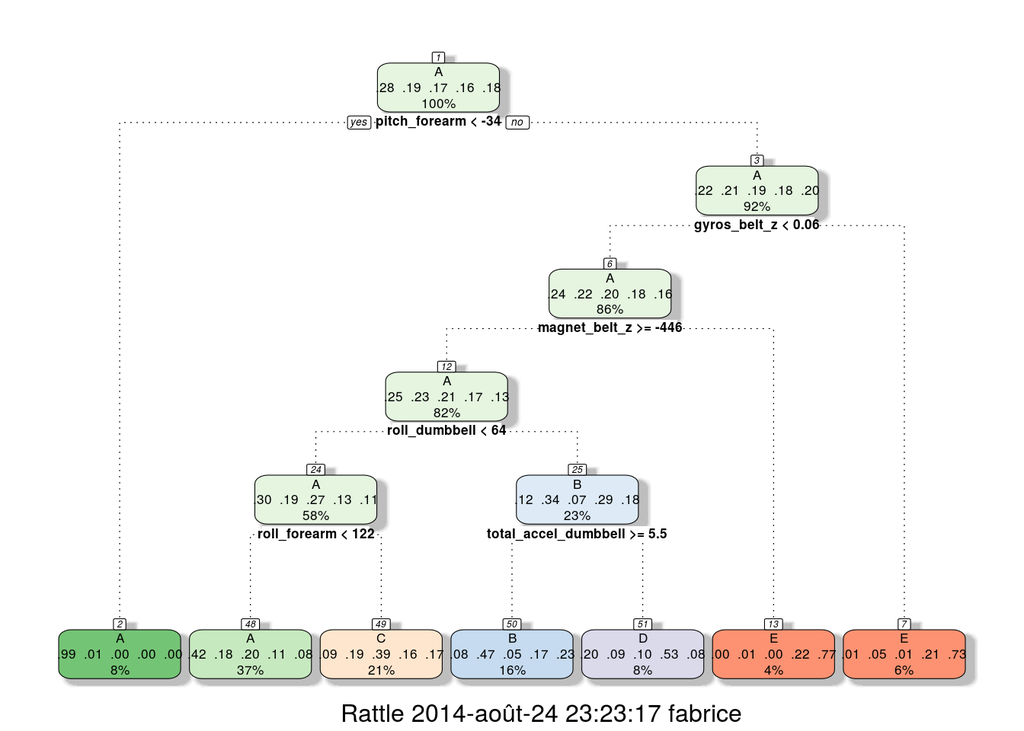

Hereafter are the confusion matrix performed on the **validation set** and its related statistics.

```
## Confusion Matrix and Statistics
##
##
## pred1    A    B    C    D    E
##     A 1841  556  611  326  243
##     B   94  577   65  207  289
##     C  148  315  627  274  279
##     D  143   46   60  310   42
##     E    6   24    5  169  589
##
## Overall Statistics
##
##                Accuracy : 0.503
##                  95% CI : (0.492, 0.514)
##     No Information Rate : 0.284
##     P-Value [Acc > NIR] : <2e-16
##
##                   Kappa : 0.356
##  Mcnemar's Test P-Value : <2e-16
##
## Statistics by Class:
##
##                      Class: A Class: B Class: C Class: D Class: E
## Sensitivity             0.825   0.3801   0.4583   0.2411   0.4085
## Specificity             0.691   0.8965   0.8432   0.9556   0.9681
## Pos Pred Value          0.515   0.4683   0.3816   0.5158   0.7427
## Neg Pred Value          0.908   0.8577   0.8805   0.8653   0.8791
## Prevalence              0.284   0.1935   0.1744   0.1639   0.1838
## Detection Rate          0.235   0.0735   0.0799   0.0395   0.0751
## Detection Prevalence    0.456   0.1570   0.2094   0.0766   0.1011
## Balanced Accuracy       0.758   0.6383   0.6507   0.5983   0.6883
```

As we can see, this model offers **poor performances** due to its high rate of misclassifications.

### 3.2 Random Forest

Our second predictive model is based on the **random forest** algorithm performed with the **randomForest** package.

Hereafter are the confusion matrix performed on the **validation set** and its related statistics.

```
## Confusion Matrix and Statistics
##
##
## pred2    A    B    C    D    E
##     A 2224   16    2    0    0
##     B    3 1493   22    0    0
##     C    2    7 1334   31    4
##     D    0    0   10 1246    3
##     E    3    2    0    9 1435
##
## Overall Statistics
##
##                Accuracy : 0.985
##                  95% CI : (0.983, 0.988)
##     No Information Rate : 0.284
##     P-Value [Acc > NIR] : <2e-16
##
##                   Kappa : 0.982
##  Mcnemar's Test P-Value : NA
##
## Statistics by Class:
##
##                      Class: A Class: B Class: C Class: D Class: E
## Sensitivity             0.996    0.984    0.975    0.969    0.995
## Specificity             0.997    0.996    0.993    0.998    0.998
## Pos Pred Value          0.992    0.984    0.968    0.990    0.990
## Neg Pred Value          0.999    0.996    0.995    0.994    0.999
## Prevalence              0.284    0.193    0.174    0.164    0.184
## Detection Rate          0.283    0.190    0.170    0.159    0.183
## Detection Prevalence    0.286    0.193    0.176    0.160    0.185
## Balanced Accuracy       0.997    0.990    0.984    0.983    0.996
```

As we see, this model shows **good performances on the validation set**. It will gives us better performances on the test set than the classification tree model.

## 4. Results

We **apply** the two models **on the test set**. According to our results on the training and validation sets, the random forest should give us the best predictions.

1. **Classification Tree**

```
##  [1] C A C A A C C A A A D C C A C A A D A C
## Levels: A B C D E
```

2. **Random Forest**

```
##  1  2  3  4  5  6  7  8  9 10 11 12 13 14 15 16 17 18 19 20
##  B  A  B  A  A  E  D  B  A  A  B  C  B  A  E  E  A  B  B  B
## Levels: A B C D E
```